```r
library(ISLR)
attach(Auto)
Auto = na.omit(Auto)
fix(Auto)
```

```r
lm.fit=lm(mpg~horsepower)
summary(lm.fit)
mean(mpg)
```

1. Is there a relationship between the predictor and the ?esponse? Yes, there is a negative relationship between mpg and horsepower. The relationship is statistically significant with the p-value for horsepower being very low and the F statistic being much larger than 1.
2. How strong is the relationship betwee? the predictor and the response? The relationship is fairly strong, explaining ~60% of the change in mpg, however we would want to raise this value, probably by turning this in to a multiple linear regression. There is fairly high error rate in our current?model too, 4.906/23.44592 = 20.92
3. Is the relationship between the predictor and the response positive or negative? Negative.
4. What is the predicted mpg associated with a horsepower of 98? What are the associated 95% confidence and prediction inte?vals?

```r
predict(lm.fit, data.frame(horsepower=98),interval = "confidence")
predict(lm.fit, data.frame(horsepower=98),interval = "prediction")
```

2. Plot the response and the predictor. Use the abline() function to display the least squares regress?on line.

```r
plot(horsepower,mpg)
abline(lm.fit)
```

3. Use the plot() function to produce diagnostic plots of the least squares regression fit. Comment on any problems you see with the fit

```r
par(mfrow=c(2,2))
plot(lm.fit)
```

9. This question involves the use of multiple linear regression on the Auto data set.
1. Produce a scatterplot matrix which includes all of the variables?in the data set.

```r
pairs(Auto)
```

2. Compute the matrix of correlations between the variables using the function cor(). You will need to exclude the name variable, which is qualitative.

```r
cor(subset(Auto, select = -name))
```

3. Use the lm(? function to perform a multiple linear regression with mpg as the response and all other variables except name as the predictors. Use the summary() function to print the results. Comment on the output. For instance:

```r
lm.fit=lm(mpg~.-name,data=Auto)
s?mmary(lm.fit)
```

1. Is there a relationship between the predictors and the response? There is a relationship between the predictors and response; the F-statistic is >> 1 and the p-value << 0.
2. Which predictors appear to have a statistically significa?t relationship to the response? Displacement, Weight, year and origin.
3. What does the coefficient for the year variable suggest? As it is >0, it suggests that as time goes on the mpg of engines has increased, at a rate of 0.75 MPG/annum.
4. Use the?plot() function to produce diagnostic plots of the linear regression fit. Comment on any problems you see with the fit. Do the residual plots suggest any unusually large outliers? Does the leverage plot identify any observations with unusually high leverag??

```r
par(mfrow=c(2,2))
plot(lm.fit)
```

5. Use the * and : symbols to fit linear regression models with interaction effects. Do any interactions appear to be statistically significant?

```r
lm2.fit = lm(mpg~displacement*weight+displacement*cylinders+displacement*?orsepower)
summary(lm2.fit)
```

```r
cor.test(displacement,weight,method='pearson')
cor.test(displacement,cylinders,method='pearson')
cor.test(displacement,horsepower,method='pearson')
```

I selected the 3 most correlated variable pairs. The interaction?between displacement:horsepower is the only statistically significant interaction term.

6. Try a few different transformations of the variables, such as log(X), ??? X, X^2 . Comment on your findings.

From our pairplot of predictors it looks like displacement, horsepower and weight all have a log-like shape. I will investigate this below to confirm my findings on a larger graphical scale.

```r
par(mfrow=c(3,2))
pl?t(mpg ~ displacement)
hist(displacement)
plot(mpg ~ horsepower)
hist(horsepower)
plot(mpg ~ weight)
hist(weight)
```

They do indeed look log-like. Let’s try a linear regression with this transformation.

```r
lm.fit3 = lm(mpg~cylinders+log(displacement)+?og(horsepower)+log(weight)+acceleration+year+origin)
par(mfrow=c(2,2))
plot(lm.fit3)
summary(lm.fit3)
```

10. This q?estion should be answered using the Carseats data set.

```r
attach(Carseats)
```

1. Fit a multiple regression model to predict Sales using Price, Urban, and US.

```r
cs.fit = lm(Sales~Price+Urban+US)
```

2. Provide an interpretation of each coeffi?ient in the model. Be careful-some of the variables in the model are qualitative!

```r
summary(cs.fit)
```

Price - negative, statistically significant relationship. As price increases, sales decrease. Urban - negative, statistically insignificant relatio?ship. US - positive, statistically significant relationship. If point of sale is in US, increase in 1201 units sold.

3. Write out the model in equation form, being careful to handle the qualitative variables properly. Where Urban = Yes, US = Yes yi = B0 ? B1xi1 + B2xi2 + B3xi3 + epsiloni Where Urban = Yes, US = No yi = B0 + B1xi1 + B2xi2 + epsiloni where Urban = No, US = Yes yi = B0 + B1xi1 + B3xi3 + epsiloni where Urban = No, US = No yi = B0 + B1xi1 + epsiloni

Finally, Where Urban = Yes, US = Yes Sales =?13.04 + -0.05446*Price + -0.021916*UrbanYes + 1.200573*USYes

4. For which of the predictors can you reject the null hypothesis H 0 : ?? j = 0? Price, USYes
5. On the basis of your response to the previous question, fit a smaller model that only uses the predictors for which there is evidence of association with the outcome.

```r
cs.fit2 = lm(Sales~Price+US)
summary(cs.fit2)
mean(Sales)
```

6. How well do the models in (a) and (e) fit the data?
1. R^2 = 0.2335, % Error = 32.98%
2. R^2 = 0.2354, % Error = 32.93%
3. is an improvement over a), however neither are stellar fits for the data, having low R^2 and high % error in the model.

?g) Using the model from (e), obtain 95% confidence intervals for the coefficient(s).

```r
confint(cs.fit2)
```

8. Is there evidence of outliers or high leverage observations in the model from (e)?

```r
par(mfrow=c(2,2))
plot(cs.fit2)
```

11. In this problem we will investigate the t-statistic for the null hypothesis H 0 : ?? = 0 in simple linear regression without an intercept. To begin, we generate a predictor x and a response y as follows.

```r
set.seed(1)
x=rnorm(100)
y=2*x+rnorm(100)
```

> set.seed(1) x=rnorm(100) y=2*x+rnorm(100)
1. Perform a simple linear reg?ession of y onto x , without an intercept. Report the coefficient estimate ^??, the standard error of this coefficient estimate, and the t-statistic and p-value associated with the null hypothesis H 0 : ?? = 0. Comment on these results. (You can perform regression without an intercept using the command lm(y???x+0) .)

```r
slr.fit=lm(y~x+0)
summary(slr.fit)
```

Over 100 values generated by rnorm, we would expect the mean value of these to be 0. When this is the case, the mean value of y would be 2x - this is what we see in our estimate of the coefficient. The ?ow p-value of the t-statistic indicates this is a statistically significant co-efficient.

2. Now perform a simple linear regression of x onto y without an intercept, and report the coefficient estimate, its standard error, and the corresponding t-statis?ic and p-values associated with the null hypothesis H 0 : ?? = 0. Comment on these results.

```r
slr.fit=lm(x~y+0)
summary(slr.fit)
```

Again, the low p-value of the t-statistic indicates this is a statistically significant co-efficient.

3. What is the relationship between the results obtained in (a) and (b)? ?oth are the same line, plotted on opposite axis pairs.
4. For the regression of Y onto X without an intercept, the t- statistic for H 0 : ?? = 0 takes the form <sup>??/SE(</sup>??), where ^?? is given by (3.38), and where (view notebook pdf, formula does not translate to plaintext)

(These formulas are slightly different from those given in Sec- tions 3.1.1 and 3.1.2, since here we are performing regression without an intercept.) Show algebrai?ally, and confirm numeri- cally in R , that the t-statistic can be written as (view notebook pdf, formula does not translate to plaintext)

```r
#Taking a) as our example
#Coefficients:
#  Estimate Std. Error t value Pr(>|t|)
#x   1.9939     0.1065  ?18.73   <2e-16 ***
#t = ^??/SE(^??)
1.9939/0.1065
#Resulting value is extremely close to the actual t statistic.
```

5. Using the results from (d), argue that the t-statistic for the re- gression of y onto x is the same as the t-statistic for the regression of x onto y .

```r
#Regress?on of y on to x
1.9939/0.1065
#Regression of x on to y
0.39111/0.02089
```

6. In R , show that when regression is performed with an intercept, the t-statistic for H 0 : ?? 1 = 0 is the same for the regression of y onto x as it is for the regression of x onto y .

```r
slr.fit3=lm(y~x)
summary(slr.fit3)
slr.fit4=lm(x~y)
summary(slr.fit4)
```

12. This problem involves simp?e linear regression without an intercept.
1. Recall that the coefficient estimate ^?? for the linear regression of Y onto X without an intercept is given by (3.38). Under what circumstance is the coefficient estimate for the regression of X onto Y the same as the coefficient estimate for the regression of Y onto X? When the sum of the squares of the observed y-values is equal to the sum of the squares of the observed x-values.
2. Generate an example in R with n = 100 observations in which the coefficient estimate for the regression of X onto Y is different from the coefficient estimate for the regression of Y onto X.

```r
set.seed(1)
x = rnorm(100)
y = x*2
lm.fit = lm(y~x)
lm.fit2 = lm(x~y)
summary(lm.fit)
```

```
essentially perfect fit: summary may be unreliable
```

```
Call:
lm(formula = y ~ x)

Residuals:
       Min         1Q     Median         3Q        Max
-3.949e-16 -3.993e-17  2.580e-18  2.946e-17  4.029e-16

Coefficients:
              Estimate Std. Error    t value Pr(>|t|)
(Intercept) -4.441e-17  1.095e-17 -4.057e+00 9.99e-05 ***
x            2.000e+00  1.216e-17  1.645e+17  < 2e-16 ***
---
Signif. codes:  0 ‘***’ 0.001 ‘**’ 0.01 ‘*’ 0.05 ‘.’ 0.1 ‘ ’ 1

Residual standard error: 1.087e-16 on 98 degrees of freedom
Multiple R-squared:      1, Adjusted R-squared:      1
F-statistic: 2.706e+34 on 1 and 98 DF,  p-value: < 2.2e-16
```

```r
summary(lm.fit2)
```

```
essentially perfect fit: summary may be unreliable
```

```
Call:
lm(formula = x ~ y)

Residuals:
       Min         1Q     Median         3Q        Max
-1.974e-16 -1.996e-17  1.289e-18  1.473e-17  2.015e-16

Coefficients:
              Estimate Std. Error    t value Pr(>|t|)
(Intercept) -2.220e-17  5.473e-18 -4.057e+00 9.99e-05 ***
y            5.000e-01  3.040e-18  1.645e+17  < 2e-16 ***
---
Signif. codes:  0 ‘***’ 0.001 ‘**’ 0.01 ‘*’ 0.05 ‘.’ 0.1 ‘ ’ 1

Residual standard error: 5.433e-17 on 98 degrees of freedom
Multiple R-squared:      1, Adjusted R-squared:      1
F-statistic: 2.706e+34 on 1 and 98 DF,  p-value: < 2.2e-16
```

3. Generate an example in R with n = 100 observations in which the coefficient estimate for the regression of X onto Y is the same as the coefficient estimate for the regression of Y onto X.

```r
y = -x
lm.fit = lm(y~x)
lm.fit2 = lm(x~y)
summary(lm.fit)
```

```
essentially perfect fit: summary may be unreliable
```

```
Call:
lm(formula = y ~ x)

Residuals:
       Min         1Q     Median         3Q        Max
-2.015e-16 -1.473e-17 -1.289e-18  1.996e-17  1.974e-16

Coefficients:
              Estimate Std. Error    t value Pr(>|t|)
(Intercept)  2.220e-17  5.473e-18  4.057e+00 9.99e-05 ***
x           -1.000e+00  6.079e-18 -1.645e+17  < 2e-16 ***
---
Signif. codes:  0 ‘***’ 0.001 ‘**’ 0.01 ‘*’ 0.05 ‘.’ 0.1 ‘ ’ 1

Residual standard error: 5.433e-17 on 98 degrees of freedom
Multiple R-squared:      1, Adjusted R-squared:      1
F-statistic: 2.706e+34 on 1 and 98 DF,  p-value: < 2.2e-16
```

```r
summary(lm.fit2)
```

```
essentially perfect fit: summary may be unreliable
```

```
Call:
lm(formula = x ~ y)

Residuals:
       Min         1Q     Median         3Q        Max
-1.974e-16 -1.996e-17  1.289e-18  1.473e-17  2.015e-16

Coefficients:
              Estimate Std. Error    t value Pr(>|t|)
(Intercept) -2.220e-17  5.473e-18 -4.057e+00 9.99e-05 ***
y           -1.000e+00  6.079e-18 -1.645e+17  < 2e-16 ***
---
Signif. codes:  0 ‘***’ 0.001 ‘**’ 0.01 ‘*’ 0.05 ‘.’ 0.1 ‘ ’ 1

Residual standard error: 5.433e-17 on 98 degrees of freedom
Multiple R-squared:      1, Adjusted R-squared:      1
F-statistic: 2.706e+34 on 1 and 98 DF,  p-value: < 2.2e-16
```

13. In this exercise you will create some simulated data and will fit simple linear regression models to it. Make sure to use set.seed(1) prior to starting part (a) to ensure consistent results.
1. Using the rnorm() function, create a vector, x , containing 100 observations drawn from a N(0,1) distribution. This represents a feature, X.
2. Using the rnorm() function, create a vector, eps , containing 100 observations drawn from a N(0,0.25) distribution i.e. a normal distribution with mean zero and variance 0.25.
3. Using x and eps , generate a vector y according to the model Y = −1 + 0.5X + ?. (3.39) What is the length of the vector y ? What are the values of β 0 and β 1 in this linear model?

```r
set.seed(1)
x = rnorm(100)
eps = rnorm(sd = sqrt(0.25),n = 100)
y = -1 +0.5*x + eps
```

Length of y = 100, β 0 = -1 and β 1 = 0.5

4. Create a scatterplot displaying the relationship between x and y . Comment on what you observe.

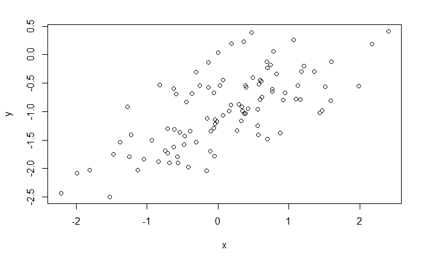

```r
plot(x,y)
```

Linear relationship.

5. Fit a least squares linear model to predict y using x . Comment on the model obtained. How do ˆβ 0 and ˆβ 1 compare to β 0 and β 1 ?

```r
lm.fit12e = lm(y~x)
summary(lm.fit12e)
```

```
Call:
lm(formula = y ~ x)

Residuals:
     Min       1Q   Median       3Q      Max
-0.93842 -0.30688 -0.06975  0.26970  1.17309

Coefficients:
            Estimate Std. Error t value Pr(>|t|)
(Intercept) -1.01885    0.04849 -21.010  < 2e-16 ***
x            0.49947    0.05386   9.273 4.58e-15 ***
---
Signif. codes:  0 ‘***’ 0.001 ‘**’ 0.01 ‘*’ 0.05 ‘.’ 0.1 ‘ ’ 1

Residual standard error: 0.4814 on 98 degrees of freedom
Multiple R-squared:  0.4674,    Adjusted R-squared:  0.4619
F-statistic: 85.99 on 1 and 98 DF,  p-value: 4.583e-15
```

Values for predicted intercept and coeff close to real values. Statistically significant.

6. Display the least squares line on the scatterplot obtained in (d). Draw the population regression line on the plot, in a different color. Use the legend() command to create an appropriate leg- end.

```r
plot(x,y)
abline(lm.fit12e, col=3)
```

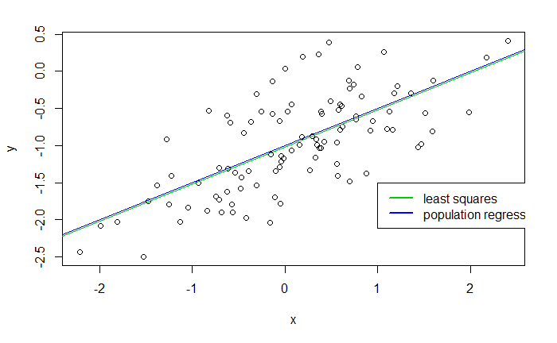

```r
abline(a=-1, b=0.5, col=4)
legend(-1.5,legend=c("least squares", "population regression"), lwd=2, col=3:4)
```

7. Now fit a polynomial regression model that predicts y using x and x 2 . Is there evidence that the quadratic term improves the model fit? Explain your answer.

```r
lm.fit12g = lm(y~x+I(x^2))
summary(lm.fit12g)
```

```
Call:
lm(formula = y ~ x + I(x^2))

Residuals:
     Min       1Q   Median       3Q      Max
-0.98252 -0.31270 -0.06441  0.29014  1.13500

Coefficients:
            Estimate Std. Error t value Pr(>|t|)
(Intercept) -0.97164    0.05883 -16.517  < 2e-16 ***
x            0.50858    0.05399   9.420  2.4e-15 ***
I(x^2)      -0.05946    0.04238  -1.403    0.164
---
Signif. codes:  0 ‘***’ 0.001 ‘**’ 0.01 ‘*’ 0.05 ‘.’ 0.1 ‘ ’ 1

Residual standard error: 0.479 on 97 degrees of freedom
Multiple R-squared:  0.4779,    Adjusted R-squared:  0.4672
F-statistic:  44.4 on 2 and 97 DF,  p-value: 2.038e-14
```

No, the qaudratic term does not improve the model fit. Although the RSE decreases and the R^2 increases, the expression has a high p-value meaning it is not statistically significant.

8. Repeat (a)–(f) after modifying the data generation process in such a way that there is less noise in the data. The model (3.39) should remain the same. You can do this by decreasing the vari- ance of the normal distribution used to generate the error term ? in (b). Describe your results.

```r
set.seed(1)
x = rnorm(100)
eps = rnorm(sd = sqrt(0.1),n = 100)
y = -1 +0.5*x + eps
plot(x,y)
lm.fit12h = lm(y~x)
summary(lm.fit12h)
```

```
Call:
lm(formula = y ~ x)

Residuals:
     Min       1Q   Median       3Q      Max
-0.59351 -0.19409 -0.04411  0.17057  0.74193

Coefficients:
            Estimate Std. Error t value Pr(>|t|)
(Intercept) -1.01192    0.03067  -32.99   <2e-16 ***
x            0.49966    0.03407   14.67   <2e-16 ***
---
Signif. codes:  0 ‘***’ 0.001 ‘**’ 0.01 ‘*’ 0.05 ‘.’ 0.1 ‘ ’ 1

Residual standard error: 0.3044 on 98 degrees of freedom
Multiple R-squared:  0.687, Adjusted R-squared:  0.6838
F-statistic: 215.1 on 1 and 98 DF,  p-value: < 2.2e-16
```

```r
abline(lm.fit12h, col=3)
```

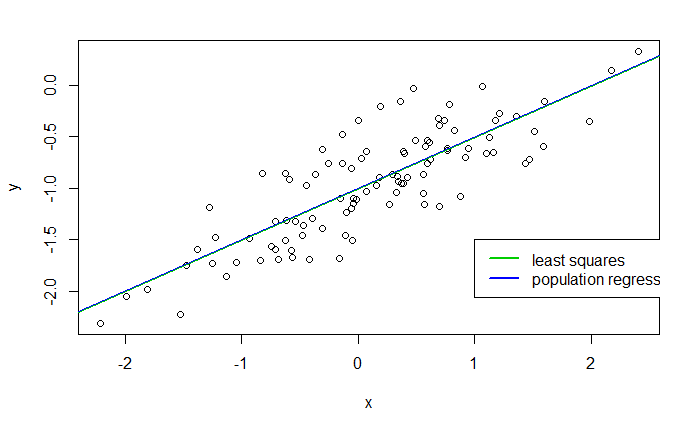

```r
abline(a=-1, b=0.5, col=4)
legend(-1.5,legend=c("least squares", "population regression"), lwd=2, col=3:4)
```

Decreasing the variance produces a better, more accurate model - the lines nearly overlap.

1. Repeat (a)–(f) after modifying the data generation process in such a way that there is more noise in the data. The model (3.39) should remain the same. You can do this by increasing the variance of the normal distribution used to generate the error term ? in (b). Describe your results.

```r
set.seed(1)
x = rnorm(100)
eps = rnorm(sd = sqrt(0.5),n = 100)
y = -1 +0.5*x + eps
plot(x,y)
lm.fit12i = lm(y~x)
summary(lm.fit12i)
```

```
Call:
lm(formula = y ~ x)

Residuals:
     Min       1Q   Median       3Q      Max
-1.32713 -0.43400 -0.09864  0.38141  1.65900

Coefficients:
            Estimate Std. Error t value Pr(>|t|)
(Intercept) -1.02665    0.06858 -14.970  < 2e-16 ***
x            0.49925    0.07617   6.554 2.62e-09 ***
---
Signif. codes:  0 ‘***’ 0.001 ‘**’ 0.01 ‘*’ 0.05 ‘.’ 0.1 ‘ ’ 1

Residual standard error: 0.6808 on 98 degrees of freedom
Multiple R-squared:  0.3047,    Adjusted R-squared:  0.2976
F-statistic: 42.96 on 1 and 98 DF,  p-value: 2.624e-09
```

```r
abline(lm.fit12i, col=3)
```

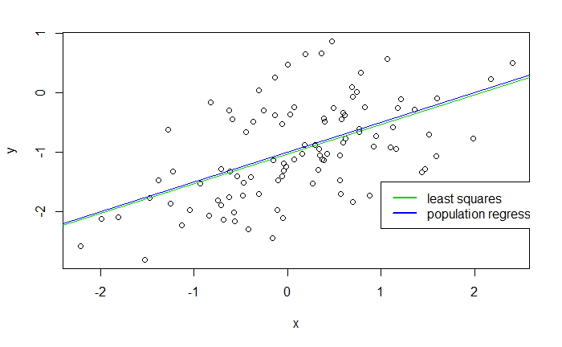

```r
abline(a=-1, b=0.5, col=4)
legend(-1.5,legend=c("least squares", "population regression"), lwd=2, col=3:4)
```

10. What are the confidence intervals for β 0 and β 1 based on the original data set, the noisier data set, and the less noisy data set? Comment on your results.

```r
confint(lm.fit12g)
```

```
                 2.5 %      97.5 %
(Intercept) -1.0883993 -0.85488570
x            0.4014226  0.61573832
I(x^2)      -0.1435788  0.02465763
```

```r
confint(lm.fit12h)
```

```
                 2.5 %     97.5 %
(Intercept) -1.0727832 -0.9510557
x            0.4320613  0.5672681
```

```r
confint(lm.fit12i)
```

```
                 2.5 %     97.5 %
(Intercept) -1.1627482 -0.8905572
x            0.3480843  0.6504160
```

As expected, less variance produces a narrower confidence interval. More variance produces a wider confidence interval.

14. This problem focuses on the collinearity problem.
1. Perform the following commands in R : > set.seed(1) > x1=runif(100) > x2=0.5*x1+rnorm(100)/10 > y=2+2*x1+0.3*x2+rnorm(100)

```r
set.seed(1)
x1=runif(100)
x2=0.5*x1+rnorm(100)/10
y=2+2*x1+0.3*x2+rnorm(100)
```

The last line corresponds to creating a linear model in which y is a function of x1 and x2 . Write out the form of the linear model. What are the regression coefficients?

y=2+2*x1+0.3*x2 + epsilon β 0 = 2 β 1 = 2 β 2 = 0.3

2. What is the correlation between x1 and x2 ? Create a scatterplot displaying the relationship between the variables.

```r
cor(x1,x2)
```

```
[1] 0.8351212
```

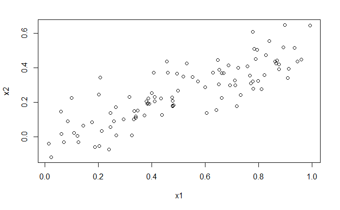

```r
plot(x1,x2)
```

3. Using this data, fit a least squares regression to predict y using x1 and x2 . Describe the results obtained. What are ˆβ 0 ,ˆβ 1 , and ˆβ 2 ?

How do these relate to the true β 0 , β 1 , and β 2 ? Can you reject the null hypothesis H 0 : β 1 = 0? How about the null hypothesis H 0 : β 2 = 0?

```r
lm.fit14c = lm(y~x1+x2)
summary(lm.fit14c)
```

```
Call:
lm(formula = y ~ x1 + x2)

Residuals:
    Min      1Q  Median      3Q     Max
-2.8311 -0.7273 -0.0537  0.6338  2.3359

Coefficients:
            Estimate Std. Error t value Pr(>|t|)
(Intercept)   2.1305     0.2319   9.188 7.61e-15 ***
x1            1.4396     0.7212   1.996   0.0487 *
x2            1.0097     1.1337   0.891   0.3754
---
Signif. codes:  0 ‘***’ 0.001 ‘**’ 0.01 ‘*’ 0.05 ‘.’ 0.1 ‘ ’ 1

Residual standard error: 1.056 on 97 degrees of freedom
Multiple R-squared:  0.2088,    Adjusted R-squared:  0.1925
F-statistic:  12.8 on 2 and 97 DF,  p-value: 1.164e-05
```

ˆβ 0 = 2.13 - Close, null hypothesis can be rejected ˆβ 1 = 1.44 - Somewhat close, null hypothesis can be rejected at the 95% confidence interval ˆβ 2 = 1.01 - Not close, cannot reject null hypothesis

4. Now fit a least squares regression to predict y using only x1 . Comment on your results. Can you reject the null hypothesis H 0 : β 1 = 0?

```r
lm.fit14d = lm(y~x1)
summary(lm.fit14d)
```

```
Call:
lm(formula = y ~ x1)

Residuals:
     Min       1Q   Median       3Q      Max
-2.89495 -0.66874 -0.07785  0.59221  2.45560

Coefficients:
            Estimate Std. Error t value Pr(>|t|)
(Intercept)   2.1124     0.2307   9.155 8.27e-15 ***
x1            1.9759     0.3963   4.986 2.66e-06 ***
---
Signif. codes:  0 ‘***’ 0.001 ‘**’ 0.01 ‘*’ 0.05 ‘.’ 0.1 ‘ ’ 1

Residual standard error: 1.055 on 98 degrees of freedom
Multiple R-squared:  0.2024,    Adjusted R-squared:  0.1942
F-statistic: 24.86 on 1 and 98 DF,  p-value: 2.661e-06
```

Much more accurate estimate for coefficient of x1, null hypothesis can be rejected with much higher certainty.

5. Now fit a least squares regression to predict y using only x2 . Comment on your results. Can you reject the null hypothesis H 0 : β 1 = 0?

```r
lm.fit14e = lm(y~x2)
summary(lm.fit14e)
```

```
Call:
lm(formula = y ~ x2)

Residuals:
     Min       1Q   Median       3Q      Max
-2.62687 -0.75156 -0.03598  0.72383  2.44890

Coefficients:
            Estimate Std. Error t value Pr(>|t|)
(Intercept)   2.3899     0.1949   12.26  < 2e-16 ***
x2            2.8996     0.6330    4.58 1.37e-05 ***
---
Signif. codes:  0 ‘***’ 0.001 ‘**’ 0.01 ‘*’ 0.05 ‘.’ 0.1 ‘ ’ 1

Residual standard error: 1.072 on 98 degrees of freedom
Multiple R-squared:  0.1763,    Adjusted R-squared:  0.1679
F-statistic: 20.98 on 1 and 98 DF,  p-value: 1.366e-05
```

Null hypothesis for x2 can be rejected with certainty.

6. Do the results obtained in (c)–(e) contradict each other? Explain your answer.

No - we saw how the two variables are highly collinear, hence the results obtained in c)-e) - when the features are considered in isolation they are both statistically significant, and their effects can be observed accurately.

7. Now suppose we obtain one additional observation, which was unfortunately mismeasured. > x1=c(x1, 0.1) > x2=c(x2, 0.8) > y=c(y,6)

```r
x1=c(x1, 0.1)
x2=c(x2, 0.8)
y=c(y,6)
```

Re-fit the linear models from (c) to (e) using this new data. What effect does this new observation have on the each of the models? In each model, is this observation an outlier? A high-leverage point? Both? Explain your answers.

```r
lm.fit14c = lm(y~x1+x2)
summary(lm.fit14c)
```

```
Call:
lm(formula = y ~ x1 + x2)

Residuals:
     Min       1Q   Median       3Q      Max
-2.73348 -0.69318 -0.05263  0.66385  2.30619

Coefficients:
            Estimate Std. Error t value Pr(>|t|)
(Intercept)   2.2267     0.2314   9.624 7.91e-16 ***
x1            0.5394     0.5922   0.911  0.36458
x2            2.5146     0.8977   2.801  0.00614 **
---
Signif. codes:  0 ‘***’ 0.001 ‘**’ 0.01 ‘*’ 0.05 ‘.’ 0.1 ‘ ’ 1

Residual standard error: 1.075 on 98 degrees of freedom
Multiple R-squared:  0.2188,    Adjusted R-squared:  0.2029
F-statistic: 13.72 on 2 and 98 DF,  p-value: 5.564e-06
```

```r
lm.fit14d = lm(y~x1)
summary(lm.fit14d)
```

```
Call:
lm(formula = y ~ x1)

Residuals:
    Min      1Q  Median      3Q     Max
-2.8897 -0.6556 -0.0909  0.5682  3.5665

Coefficients:
            Estimate Std. Error t value Pr(>|t|)
(Intercept)   2.2569     0.2390   9.445 1.78e-15 ***
x1            1.7657     0.4124   4.282 4.29e-05 ***
---
Signif. codes:  0 ‘***’ 0.001 ‘**’ 0.01 ‘*’ 0.05 ‘.’ 0.1 ‘ ’ 1

Residual standard error: 1.111 on 99 degrees of freedom
Multiple R-squared:  0.1562,    Adjusted R-squared:  0.1477
F-statistic: 18.33 on 1 and 99 DF,  p-value: 4.295e-05
```

```r
lm.fit14e = lm(y~x2)
summary(lm.fit14e)
```

```
Call:
lm(formula = y ~ x2)

Residuals:
     Min       1Q   Median       3Q      Max
-2.64729 -0.71021 -0.06899  0.72699  2.38074

Coefficients:
            Estimate Std. Error t value Pr(>|t|)
(Intercept)   2.3451     0.1912  12.264  < 2e-16 ***
x2            3.1190     0.6040   5.164 1.25e-06 ***
---
Signif. codes:  0 ‘***’ 0.001 ‘**’ 0.01 ‘*’ 0.05 ‘.’ 0.1 ‘ ’ 1

Residual standard error: 1.074 on 99 degrees of freedom
Multiple R-squared:  0.2122,    Adjusted R-squared:  0.2042
F-statistic: 26.66 on 1 and 99 DF,  p-value: 1.253e-06
```

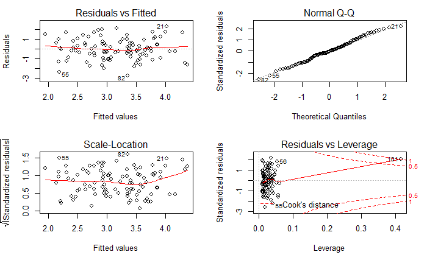

```r
par(mfrow=c(2,2))
plot(lm.fit14c)
par(mfrow=c(2,2))
```

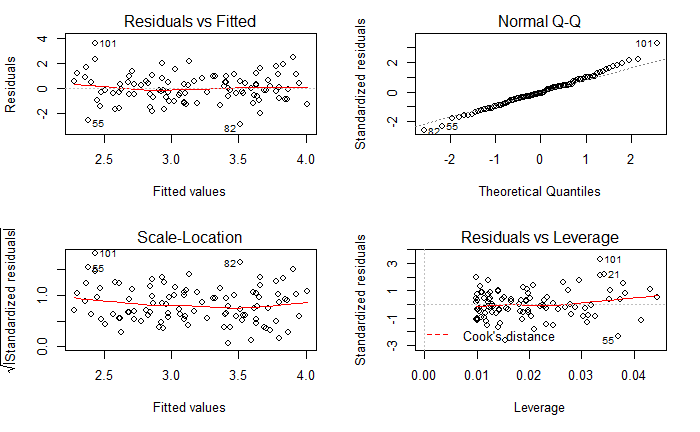

```r
plot(lm.fit14d)
par(mfrow=c(2,2))
```

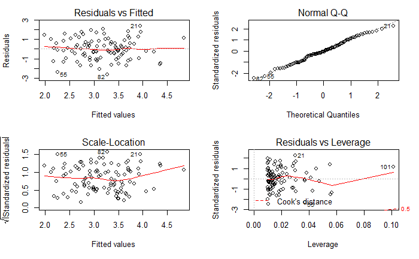

```r
plot(lm.fit14e)
```

The addition of this data point pushes x1 in to statistical insginificance and x2 in to significance in the multivariate model. For our plots of x1+x2 and x2 we can see the point is a high leverage point. For our plot of x1 we can see it is an outlier.

15. This problem involves the Boston data set, which we saw in the lab for this chapter. We will now try to predict per capita crime rate using the other variables in this data set. In other words, per capita crime rate is the response, and the other variables are the predictors.

```r
library(MASS)
attach(Boston)
Boston$chas <- factor(Boston$chas, labels = c('N','Y'))
summary(Boston)
```

```
      crim                zn             indus       chas         nox               rm             age              dis              rad
 Min.   : 0.00632   Min.   :  0.00   Min.   : 0.46   N:471   Min.   :0.3850   Min.   :3.561   Min.   :  2.90   Min.   : 1.130   Min.   : 1.000
 1st Qu.: 0.08204   1st Qu.:  0.00   1st Qu.: 5.19   Y: 35   1st Qu.:0.4490   1st Qu.:5.886   1st Qu.: 45.02   1st Qu.: 2.100   1st Qu.: 4.000
 Median : 0.25651   Median :  0.00   Median : 9.69           Median :0.5380   Median :6.208   Median : 77.50   Median : 3.207   Median : 5.000
 Mean   : 3.61352   Mean   : 11.36   Mean   :11.14           Mean   :0.5547   Mean   :6.285   Mean   : 68.57   Mean   : 3.795   Mean   : 9.549
 3rd Qu.: 3.67708   3rd Qu.: 12.50   3rd Qu.:18.10           3rd Qu.:0.6240   3rd Qu.:6.623   3rd Qu.: 94.08   3rd Qu.: 5.188   3rd Qu.:24.000
 Max.   :88.97620   Max.   :100.00   Max.   :27.74           Max.   :0.8710   Max.   :8.780   Max.   :100.00   Max.   :12.127   Max.   :24.000
      tax           ptratio          black            lstat            medv
 Min.   :187.0   Min.   :12.60   Min.   :  0.32   Min.   : 1.73   Min.   : 5.00
 1st Qu.:279.0   1st Qu.:17.40   1st Qu.:375.38   1st Qu.: 6.95   1st Qu.:17.02
 Median :330.0   Median :19.05   Median :391.44   Median :11.36   Median :21.20
 Mean   :408.2   Mean   :18.46   Mean   :356.67   Mean   :12.65   Mean   :22.53
 3rd Qu.:666.0   3rd Qu.:20.20   3rd Qu.:396.23   3rd Qu.:16.95   3rd Qu.:25.00
 Max.   :711.0   Max.   :22.00   Max.   :396.90   Max.   :37.97   Max.   :50.00
```

1. For each predictor, fit a simple linear regression model to predict the response. Describe your results. In which of the models is there a statistically significant association between the predictor and the response? Create some plots to back up your assertions.

```r
lm.zn = lm(crim~zn)
summary(lm.zn)
```

```
Call:
lm(formula = crim ~ zn)

Residuals:
   Min     1Q Median     3Q    Max
-4.429 -4.222 -2.620  1.250 84.523

Coefficients:
            Estimate Std. Error t value Pr(>|t|)
(Intercept)  4.45369    0.41722  10.675  < 2e-16 ***
zn          -0.07393    0.01609  -4.594 5.51e-06 ***
---
Signif. codes:  0 ‘***’ 0.001 ‘**’ 0.01 ‘*’ 0.05 ‘.’ 0.1 ‘ ’ 1

Residual standard error: 8.435 on 504 degrees of freedom
Multiple R-squared:  0.04019,   Adjusted R-squared:  0.03828
F-statistic:  21.1 on 1 and 504 DF,  p-value: 5.506e-06
```

```r
lm.indus = lm(crim~indus)
summary(lm.indus)
```

```
Call:
lm(formula = crim ~ indus)

Residuals:
    Min      1Q  Median      3Q     Max
-11.972  -2.698  -0.736   0.712  81.813

Coefficients:
            Estimate Std. Error t value Pr(>|t|)
(Intercept) -2.06374    0.66723  -3.093  0.00209 **
indus        0.50978    0.05102   9.991  < 2e-16 ***
---
Signif. codes:  0 ‘***’ 0.001 ‘**’ 0.01 ‘*’ 0.05 ‘.’ 0.1 ‘ ’ 1

Residual standard error: 7.866 on 504 degrees of freedom
Multiple R-squared:  0.1653,    Adjusted R-squared:  0.1637
F-statistic: 99.82 on 1 and 504 DF,  p-value: < 2.2e-16
```

```r
lm.chas = lm(crim~chas)
summary(lm.chas)
```

```
Call:
lm(formula = crim ~ chas)

Residuals:
   Min     1Q Median     3Q    Max
-3.738 -3.661 -3.435  0.018 85.232

Coefficients:
            Estimate Std. Error t value Pr(>|t|)
(Intercept)   3.7444     0.3961   9.453   <2e-16 ***
chas         -1.8928     1.5061  -1.257    0.209
---
Signif. codes:  0 ‘***’ 0.001 ‘**’ 0.01 ‘*’ 0.05 ‘.’ 0.1 ‘ ’ 1

Residual standard error: 8.597 on 504 degrees of freedom
Multiple R-squared:  0.003124,  Adjusted R-squared:  0.001146
F-statistic: 1.579 on 1 and 504 DF,  p-value: 0.2094
```

```r
lm.nox = lm(crim~nox)
summary(lm.nox)
```

```
Call:
lm(formula = crim ~ nox)

Residuals:
    Min      1Q  Median      3Q     Max
-12.371  -2.738  -0.974   0.559  81.728

Coefficients:
            Estimate Std. Error t value Pr(>|t|)
(Intercept)  -13.720      1.699  -8.073 5.08e-15 ***
nox           31.249      2.999  10.419  < 2e-16 ***
---
Signif. codes:  0 ‘***’ 0.001 ‘**’ 0.01 ‘*’ 0.05 ‘.’ 0.1 ‘ ’ 1

Residual standard error: 7.81 on 504 degrees of freedom
Multiple R-squared:  0.1772,    Adjusted R-squared:  0.1756
F-statistic: 108.6 on 1 and 504 DF,  p-value: < 2.2e-16
```

```r
lm.rm = lm(crim~rm)
summary(lm.rm)
```

```
Call:
lm(formula = crim ~ rm)

Residuals:
   Min     1Q Median     3Q    Max
-6.604 -3.952 -2.654  0.989 87.197

Coefficients:
            Estimate Std. Error t value Pr(>|t|)
(Intercept)   20.482      3.365   6.088 2.27e-09 ***
rm            -2.684      0.532  -5.045 6.35e-07 ***
---
Signif. codes:  0 ‘***’ 0.001 ‘**’ 0.01 ‘*’ 0.05 ‘.’ 0.1 ‘ ’ 1

Residual standard error: 8.401 on 504 degrees of freedom
Multiple R-squared:  0.04807,   Adjusted R-squared:  0.04618
F-statistic: 25.45 on 1 and 504 DF,  p-value: 6.347e-07
```

```r
lm.age = lm(crim~age)
summary(lm.age)
```

```
Call:
lm(formula = crim ~ age)

Residuals:
   Min     1Q Median     3Q    Max
-6.789 -4.257 -1.230  1.527 82.849

Coefficients:
            Estimate Std. Error t value Pr(>|t|)
(Intercept) -3.77791    0.94398  -4.002 7.22e-05 ***
age          0.10779    0.01274   8.463 2.85e-16 ***
---
Signif. codes:  0 ‘***’ 0.001 ‘**’ 0.01 ‘*’ 0.05 ‘.’ 0.1 ‘ ’ 1

Residual standard error: 8.057 on 504 degrees of freedom
Multiple R-squared:  0.1244,    Adjusted R-squared:  0.1227
F-statistic: 71.62 on 1 and 504 DF,  p-value: 2.855e-16
```

```r
lm.dis = lm(crim~dis)
summary(lm.dis)
```

```
Call:
lm(formula = crim ~ dis)

Residuals:
   Min     1Q Median     3Q    Max
-6.708 -4.134 -1.527  1.516 81.674

Coefficients:
            Estimate Std. Error t value Pr(>|t|)
(Intercept)   9.4993     0.7304  13.006   <2e-16 ***
dis          -1.5509     0.1683  -9.213   <2e-16 ***
---
Signif. codes:  0 ‘***’ 0.001 ‘**’ 0.01 ‘*’ 0.05 ‘.’ 0.1 ‘ ’ 1

Residual standard error: 7.965 on 504 degrees of freedom
Multiple R-squared:  0.1441,    Adjusted R-squared:  0.1425
F-statistic: 84.89 on 1 and 504 DF,  p-value: < 2.2e-16
```

```r
lm.rad = lm(crim~rad)
summary(lm.rad)
```

```
Call:
lm(formula = crim ~ rad)

Residuals:
    Min      1Q  Median      3Q     Max
-10.164  -1.381  -0.141   0.660  76.433

Coefficients:
            Estimate Std. Error t value Pr(>|t|)
(Intercept) -2.28716    0.44348  -5.157 3.61e-07 ***
rad          0.61791    0.03433  17.998  < 2e-16 ***
---
Signif. codes:  0 ‘***’ 0.001 ‘**’ 0.01 ‘*’ 0.05 ‘.’ 0.1 ‘ ’ 1

Residual standard error: 6.718 on 504 degrees of freedom
Multiple R-squared:  0.3913,    Adjusted R-squared:   0.39
F-statistic: 323.9 on 1 and 504 DF,  p-value: < 2.2e-16
```

```r
lm.tax = lm(crim~tax)
summary(lm.tax)
```

```
Call:
lm(formula = crim ~ tax)

Residuals:
    Min      1Q  Median      3Q     Max
-12.513  -2.738  -0.194   1.065  77.696

Coefficients:
             Estimate Std. Error t value Pr(>|t|)
(Intercept) -8.528369   0.815809  -10.45   <2e-16 ***
tax          0.029742   0.001847   16.10   <2e-16 ***
---
Signif. codes:  0 ‘***’ 0.001 ‘**’ 0.01 ‘*’ 0.05 ‘.’ 0.1 ‘ ’ 1

Residual standard error: 6.997 on 504 degrees of freedom
Multiple R-squared:  0.3396,    Adjusted R-squared:  0.3383
F-statistic: 259.2 on 1 and 504 DF,  p-value: < 2.2e-16
```

```r
lm.ptratio = lm(crim~ptratio)
summary(lm.ptratio)
```

```
Call:
lm(formula = crim ~ ptratio)

Residuals:
   Min     1Q Median     3Q    Max
-7.654 -3.985 -1.912  1.825 83.353

Coefficients:
            Estimate Std. Error t value Pr(>|t|)
(Intercept) -17.6469     3.1473  -5.607 3.40e-08 ***
ptratio       1.1520     0.1694   6.801 2.94e-11 ***
---
Signif. codes:  0 ‘***’ 0.001 ‘**’ 0.01 ‘*’ 0.05 ‘.’ 0.1 ‘ ’ 1

Residual standard error: 8.24 on 504 degrees of freedom
Multiple R-squared:  0.08407,   Adjusted R-squared:  0.08225
F-statistic: 46.26 on 1 and 504 DF,  p-value: 2.943e-11
```

```r
lm.black = lm(crim~black)
summary(lm.black)
```

```
Call:
lm(formula = crim ~ black)

Residuals:
    Min      1Q  Median      3Q     Max
-13.756  -2.299  -2.095  -1.296  86.822

Coefficients:
             Estimate Std. Error t value Pr(>|t|)
(Intercept) 16.553529   1.425903  11.609   <2e-16 ***
black       -0.036280   0.003873  -9.367   <2e-16 ***
---
Signif. codes:  0 ‘***’ 0.001 ‘**’ 0.01 ‘*’ 0.05 ‘.’ 0.1 ‘ ’ 1

Residual standard error: 7.946 on 504 degrees of freedom
Multiple R-squared:  0.1483,    Adjusted R-squared:  0.1466
F-statistic: 87.74 on 1 and 504 DF,  p-value: < 2.2e-16
```

```r
lm.lstat = lm(crim~lstat)
summary(lm.lstat)
```

```
Call:
lm(formula = crim ~ lstat)

Residuals:
    Min      1Q  Median      3Q     Max
-13.925  -2.822  -0.664   1.079  82.862

Coefficients:
            Estimate Std. Error t value Pr(>|t|)
(Intercept) -3.33054    0.69376  -4.801 2.09e-06 ***
lstat        0.54880    0.04776  11.491  < 2e-16 ***
---
Signif. codes:  0 ‘***’ 0.001 ‘**’ 0.01 ‘*’ 0.05 ‘.’ 0.1 ‘ ’ 1

Residual standard error: 7.664 on 504 degrees of freedom
Multiple R-squared:  0.2076,    Adjusted R-squared:  0.206
F-statistic:   132 on 1 and 504 DF,  p-value: < 2.2e-16
```

```r
lm.medv = lm(crim~medv)
summary(lm.medv)
```

```
Call:
lm(formula = crim ~ medv)

Residuals:
   Min     1Q Median     3Q    Max
-9.071 -4.022 -2.343  1.298 80.957

Coefficients:
            Estimate Std. Error t value Pr(>|t|)
(Intercept) 11.79654    0.93419   12.63   <2e-16 ***
medv        -0.36316    0.03839   -9.46   <2e-16 ***
---
Signif. codes:  0 ‘***’ 0.001 ‘**’ 0.01 ‘*’ 0.05 ‘.’ 0.1 ‘ ’ 1

Residual standard error: 7.934 on 504 degrees of freedom
Multiple R-squared:  0.1508,    Adjusted R-squared:  0.1491
F-statistic: 89.49 on 1 and 504 DF,  p-value: < 2.2e-16
```

All except chas are significant.

2. Fit a multiple regression model to predict the response using all of the predictors. Describe your results. For which predictors can we reject the null hypothesis H 0 : β j = 0?

```r
lm.fit15b = lm(crim~.,data=Boston)
summary(lm.fit15b)
```

```
Call:
lm(formula = crim ~ ., data = Boston)

Residuals:
   Min     1Q Median     3Q    Max
-9.924 -2.120 -0.353  1.019 75.051

Coefficients:
              Estimate Std. Error t value Pr(>|t|)
(Intercept)  17.033228   7.234903   2.354 0.018949 *
zn            0.044855   0.018734   2.394 0.017025 *
indus        -0.063855   0.083407  -0.766 0.444294
chasY        -0.749134   1.180147  -0.635 0.525867
nox         -10.313535   5.275536  -1.955 0.051152 .
rm            0.430131   0.612830   0.702 0.483089
age           0.001452   0.017925   0.081 0.935488
dis          -0.987176   0.281817  -3.503 0.000502 ***
rad           0.588209   0.088049   6.680 6.46e-11 ***
tax          -0.003780   0.005156  -0.733 0.463793
ptratio      -0.271081   0.186450  -1.454 0.146611
black        -0.007538   0.003673  -2.052 0.040702 *
lstat         0.126211   0.075725   1.667 0.096208 .
medv         -0.198887   0.060516  -3.287 0.001087 **
---
Signif. codes:  0 ‘***’ 0.001 ‘**’ 0.01 ‘*’ 0.05 ‘.’ 0.1 ‘ ’ 1

Residual standard error: 6.439 on 492 degrees of freedom
Multiple R-squared:  0.454, Adjusted R-squared:  0.4396
F-statistic: 31.47 on 13 and 492 DF,  p-value: < 2.2e-16
```

The null hypothesis can be rejected for zn, dis, rad, black, medv. nox could also be considered as it’s p-value is very close to the 95% threshold.

3. How do your results from (a) compare to your results from (b)? Create a plot displaying the univariate regression coefficients from (a) on the x-axis, and the multiple regression coefficients from (b) on the y-axis. That is, each predictor is displayed as a single point in the plot. Its coefficient in a simple linear regres- sion model is shown on the x-axis, and its coefficient estimate in the multiple linear regression model is shown on the y-axis.

Many fewer features are significant in our multivariate model compared to our simple model.

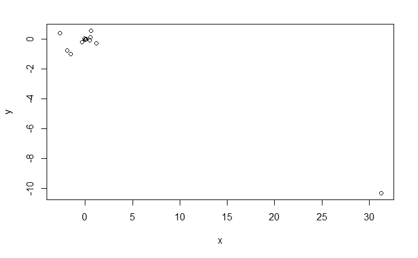

```r
x = c(coefficients(lm.zn)[2],
      coefficients(lm.indus)[2],
      coefficients(lm.chas)[2],
      coefficients(lm.nox)[2],
      coefficients(lm.rm)[2],
      coefficients(lm.age)[2],
      coefficients(lm.dis)[2],
      coefficients(lm.rad)[2],
      coefficients(lm.tax)[2],
      coefficients(lm.ptratio)[2],
      coefficients(lm.black)[2],
      coefficients(lm.lstat)[2],
      coefficients(lm.medv)[2])
y = coefficients(lm.fit15b)[2:14]
plot(x, y)
```

The value for nox is significantly different in the simple regression compared to the multivariate model.

4. Is there evidence of non-linear association between any of the predictors and the response? To answer this question, for each predictor X, fit a model of the form Y = β 0 + β 1 X + β 2 X 2 + β 3 X 3 + ?.

```r
lm.zn = lm(crim~poly(zn,3))
summary(lm.zn)
```

```
Call:
lm(formula = crim ~ poly(zn, 3))

Residuals:
   Min     1Q Median     3Q    Max
-4.821 -4.614 -1.294  0.473 84.130

Coefficients:
             Estimate Std. Error t value Pr(>|t|)
(Intercept)    3.6135     0.3722   9.709  < 2e-16 ***
poly(zn, 3)1 -38.7498     8.3722  -4.628  4.7e-06 ***
poly(zn, 3)2  23.9398     8.3722   2.859  0.00442 **
poly(zn, 3)3 -10.0719     8.3722  -1.203  0.22954
---
Signif. codes:  0 ‘***’ 0.001 ‘**’ 0.01 ‘*’ 0.05 ‘.’ 0.1 ‘ ’ 1

Residual standard error: 8.372 on 502 degrees of freedom
Multiple R-squared:  0.05824,   Adjusted R-squared:  0.05261
F-statistic: 10.35 on 3 and 502 DF,  p-value: 1.281e-06
```

```r
lm.indus = lm(crim~poly(indus,3))
summary(lm.indus)
```

```
Call:
lm(formula = crim ~ poly(indus, 3))

Residuals:
   Min     1Q Median     3Q    Max
-8.278 -2.514  0.054  0.764 79.713

Coefficients:
                Estimate Std. Error t value Pr(>|t|)
(Intercept)        3.614      0.330  10.950  < 2e-16 ***
poly(indus, 3)1   78.591      7.423  10.587  < 2e-16 ***
poly(indus, 3)2  -24.395      7.423  -3.286  0.00109 **
poly(indus, 3)3  -54.130      7.423  -7.292  1.2e-12 ***
---
Signif. codes:  0 ‘***’ 0.001 ‘**’ 0.01 ‘*’ 0.05 ‘.’ 0.1 ‘ ’ 1

Residual standard error: 7.423 on 502 degrees of freedom
Multiple R-squared:  0.2597,    Adjusted R-squared:  0.2552
F-statistic: 58.69 on 3 and 502 DF,  p-value: < 2.2e-16
```

```r
lm.nox = lm(crim~poly(nox,3))
summary(lm.nox)
```

```
Call:
lm(formula = crim ~ poly(nox, 3))

Residuals:
   Min     1Q Median     3Q    Max
-9.110 -2.068 -0.255  0.739 78.302

Coefficients:
              Estimate Std. Error t value Pr(>|t|)
(Intercept)     3.6135     0.3216  11.237  < 2e-16 ***
poly(nox, 3)1  81.3720     7.2336  11.249  < 2e-16 ***
poly(nox, 3)2 -28.8286     7.2336  -3.985 7.74e-05 ***
poly(nox, 3)3 -60.3619     7.2336  -8.345 6.96e-16 ***
---
Signif. codes:  0 ‘***’ 0.001 ‘**’ 0.01 ‘*’ 0.05 ‘.’ 0.1 ‘ ’ 1

Residual standard error: 7.234 on 502 degrees of freedom
Multiple R-squared:  0.297, Adjusted R-squared:  0.2928
F-statistic: 70.69 on 3 and 502 DF,  p-value: < 2.2e-16
```

```r
lm.rm = lm(crim~poly(rm,3))
summary(lm.rm)
```

```
Call:
lm(formula = crim ~ poly(rm, 3))

Residuals:
    Min      1Q  Median      3Q     Max
-18.485  -3.468  -2.221  -0.015  87.219

Coefficients:
             Estimate Std. Error t value Pr(>|t|)
(Intercept)    3.6135     0.3703   9.758  < 2e-16 ***
poly(rm, 3)1 -42.3794     8.3297  -5.088 5.13e-07 ***
poly(rm, 3)2  26.5768     8.3297   3.191  0.00151 **
poly(rm, 3)3  -5.5103     8.3297  -0.662  0.50858
---
Signif. codes:  0 ‘***’ 0.001 ‘**’ 0.01 ‘*’ 0.05 ‘.’ 0.1 ‘ ’ 1

Residual standard error: 8.33 on 502 degrees of freedom
Multiple R-squared:  0.06779,   Adjusted R-squared:  0.06222
F-statistic: 12.17 on 3 and 502 DF,  p-value: 1.067e-07
```

```r
lm.age = lm(crim~poly(age,3))
summary(lm.age)
```

```
Call:
lm(formula = crim ~ poly(age, 3))

Residuals:
   Min     1Q Median     3Q    Max
-9.762 -2.673 -0.516  0.019 82.842

Coefficients:
              Estimate Std. Error t value Pr(>|t|)
(Intercept)     3.6135     0.3485  10.368  < 2e-16 ***
poly(age, 3)1  68.1820     7.8397   8.697  < 2e-16 ***
poly(age, 3)2  37.4845     7.8397   4.781 2.29e-06 ***
poly(age, 3)3  21.3532     7.8397   2.724  0.00668 **
---
Signif. codes:  0 ‘***’ 0.001 ‘**’ 0.01 ‘*’ 0.05 ‘.’ 0.1 ‘ ’ 1

Residual standard error: 7.84 on 502 degrees of freedom
Multiple R-squared:  0.1742,    Adjusted R-squared:  0.1693
F-statistic: 35.31 on 3 and 502 DF,  p-value: < 2.2e-16
```

```r
lm.dis = lm(crim~poly(dis,3))
summary(lm.dis)
```

```
Call:
lm(formula = crim ~ poly(dis, 3))

Residuals:
    Min      1Q  Median      3Q     Max
-10.757  -2.588   0.031   1.267  76.378

Coefficients:
              Estimate Std. Error t value Pr(>|t|)
(Intercept)     3.6135     0.3259  11.087  < 2e-16 ***
poly(dis, 3)1 -73.3886     7.3315 -10.010  < 2e-16 ***
poly(dis, 3)2  56.3730     7.3315   7.689 7.87e-14 ***
poly(dis, 3)3 -42.6219     7.3315  -5.814 1.09e-08 ***
---
Signif. codes:  0 ‘***’ 0.001 ‘**’ 0.01 ‘*’ 0.05 ‘.’ 0.1 ‘ ’ 1

Residual standard error: 7.331 on 502 degrees of freedom
Multiple R-squared:  0.2778,    Adjusted R-squared:  0.2735
F-statistic: 64.37 on 3 and 502 DF,  p-value: < 2.2e-16
```

```r
lm.rad = lm(crim~poly(rad,3))
summary(lm.rad)
```

```
Call:
lm(formula = crim ~ poly(rad, 3))

Residuals:
    Min      1Q  Median      3Q     Max
-10.381  -0.412  -0.269   0.179  76.217

Coefficients:
              Estimate Std. Error t value Pr(>|t|)
(Intercept)     3.6135     0.2971  12.164  < 2e-16 ***
poly(rad, 3)1 120.9074     6.6824  18.093  < 2e-16 ***
poly(rad, 3)2  17.4923     6.6824   2.618  0.00912 **
poly(rad, 3)3   4.6985     6.6824   0.703  0.48231
---
Signif. codes:  0 ‘***’ 0.001 ‘**’ 0.01 ‘*’ 0.05 ‘.’ 0.1 ‘ ’ 1

Residual standard error: 6.682 on 502 degrees of freedom
Multiple R-squared:    0.4, Adjusted R-squared:  0.3965
F-statistic: 111.6 on 3 and 502 DF,  p-value: < 2.2e-16
```

```r
lm.tax = lm(crim~poly(tax,3))
summary(lm.tax)
```

```
Call:
lm(formula = crim ~ poly(tax, 3))

Residuals:
    Min      1Q  Median      3Q     Max
-13.273  -1.389   0.046   0.536  76.950

Coefficients:
              Estimate Std. Error t value Pr(>|t|)
(Intercept)     3.6135     0.3047  11.860  < 2e-16 ***
poly(tax, 3)1 112.6458     6.8537  16.436  < 2e-16 ***
poly(tax, 3)2  32.0873     6.8537   4.682 3.67e-06 ***
poly(tax, 3)3  -7.9968     6.8537  -1.167    0.244
---
Signif. codes:  0 ‘***’ 0.001 ‘**’ 0.01 ‘*’ 0.05 ‘.’ 0.1 ‘ ’ 1

Residual standard error: 6.854 on 502 degrees of freedom
Multiple R-squared:  0.3689,    Adjusted R-squared:  0.3651
F-statistic:  97.8 on 3 and 502 DF,  p-value: < 2.2e-16
```

```r
lm.ptratio = lm(crim~poly(ptratio,3))
summary(lm.ptratio)
```

```
Call:
lm(formula = crim ~ poly(ptratio, 3))

Residuals:
   Min     1Q Median     3Q    Max
-6.833 -4.146 -1.655  1.408 82.697

Coefficients:
                  Estimate Std. Error t value Pr(>|t|)
(Intercept)          3.614      0.361  10.008  < 2e-16 ***
poly(ptratio, 3)1   56.045      8.122   6.901 1.57e-11 ***
poly(ptratio, 3)2   24.775      8.122   3.050  0.00241 **
poly(ptratio, 3)3  -22.280      8.122  -2.743  0.00630 **
---
Signif. codes:  0 ‘***’ 0.001 ‘**’ 0.01 ‘*’ 0.05 ‘.’ 0.1 ‘ ’ 1

Residual standard error: 8.122 on 502 degrees of freedom
Multiple R-squared:  0.1138,    Adjusted R-squared:  0.1085
F-statistic: 21.48 on 3 and 502 DF,  p-value: 4.171e-13
```

```r
lm.black = lm(crim~poly(black,3))
summary(lm.black)
```

```
Call:
lm(formula = crim ~ poly(black, 3))

Residuals:
    Min      1Q  Median      3Q     Max
-13.096  -2.343  -2.128  -1.439  86.790

Coefficients:
                Estimate Std. Error t value Pr(>|t|)
(Intercept)       3.6135     0.3536  10.218   <2e-16 ***
poly(black, 3)1 -74.4312     7.9546  -9.357   <2e-16 ***
poly(black, 3)2   5.9264     7.9546   0.745    0.457
poly(black, 3)3  -4.8346     7.9546  -0.608    0.544
---
Signif. codes:  0 ‘***’ 0.001 ‘**’ 0.01 ‘*’ 0.05 ‘.’ 0.1 ‘ ’ 1

Residual standard error: 7.955 on 502 degrees of freedom
Multiple R-squared:  0.1498,    Adjusted R-squared:  0.1448
F-statistic: 29.49 on 3 and 502 DF,  p-value: < 2.2e-16
```

```r
lm.lstat = lm(crim~poly(lstat,3))
summary(lm.lstat)
```

```
Call:
lm(formula = crim ~ poly(lstat, 3))

Residuals:
    Min      1Q  Median      3Q     Max
-15.234  -2.151  -0.486   0.066  83.353

Coefficients:
                Estimate Std. Error t value Pr(>|t|)
(Intercept)       3.6135     0.3392  10.654   <2e-16 ***
poly(lstat, 3)1  88.0697     7.6294  11.543   <2e-16 ***
poly(lstat, 3)2  15.8882     7.6294   2.082   0.0378 *
poly(lstat, 3)3 -11.5740     7.6294  -1.517   0.1299
---
Signif. codes:  0 ‘***’ 0.001 ‘**’ 0.01 ‘*’ 0.05 ‘.’ 0.1 ‘ ’ 1

Residual standard error: 7.629 on 502 degrees of freedom
Multiple R-squared:  0.2179,    Adjusted R-squared:  0.2133
F-statistic: 46.63 on 3 and 502 DF,  p-value: < 2.2e-16
```

```r
lm.medv = lm(crim~poly(medv,3))
summary(lm.medv)
```

```
Call:
lm(formula = crim ~ poly(medv, 3))

Residuals:
    Min      1Q  Median      3Q     Max
-24.427  -1.976  -0.437   0.439  73.655

Coefficients:
               Estimate Std. Error t value Pr(>|t|)
(Intercept)       3.614      0.292  12.374  < 2e-16 ***
poly(medv, 3)1  -75.058      6.569 -11.426  < 2e-16 ***
poly(medv, 3)2   88.086      6.569  13.409  < 2e-16 ***
poly(medv, 3)3  -48.033      6.569  -7.312 1.05e-12 ***
---
Signif. codes:  0 ‘***’ 0.001 ‘**’ 0.01 ‘*’ 0.05 ‘.’ 0.1 ‘ ’ 1

Residual standard error: 6.569 on 502 degrees of freedom
Multiple R-squared:  0.4202,    Adjusted R-squared:  0.4167
F-statistic: 121.3 on 3 and 502 DF,  p-value: < 2.2e-16
```

The below numbers represent the order of the polynomial expressions for each feature that have statistical significance. The only two that have no significant polynomial represenations are chas, where a polynomial expression does not exist, and black whose only significant represenation is itself.

```
  zn - 1,2
  indus - 1,2,3
  nox - 1,2,3
    chas - 1
  rm - 1,2
  age - 1,2,3
  dis - 1,2,3
  rad - 1,2
  tax - 1,2
  ptratio - 1,2,3
  black - 1
  lstat - 1,2
  medv - 1,2,3
```